```python
>>> !date
```

```
samedi 30 juillet 2016, 16:13:08 (UTC+0200)
```

# Description of the propagation environment

The `Layout` class contains the data structure for describing a propagation environment. It contains different graphs helping the implementation of the ray tracing. The class is implemented in the

[layout.py](http://pylayers.github.io/pylayers/modules/pylayers.gis.layout.html)

```python
>>> from pylayers.gis.layout import *
>>> from IPython.display import Image
>>> import os
>>> %matplotlib inline
```

## Getting the list of all available Layouts : the `ls()` method

Creating a default Layout is as simple as :

```python
>>> L=Layout()
>>> L
```

```
----------------
newfile.ini
----------------

Number of points  : 0
Number of segments  : 0
Number of sub segments  : 0
Number of cycles  : 0
Number of rooms  : 0

xrange :(-50, 50)
yrange :(-50, 50)

Useful dictionnaries
----------------
name :  {slab :seglist}

Useful arrays
----------------

Useful tip
----------------
Point p in Gs => p_coord:
Segment s in Gs => s_ab coordinates
s -> u = self.tgs[s] -> v = self.tahe[:,u] -> s_ab = self.pt[:,v]
```

Querying the file name associated with the Layout.

```python
>>> L._filename
```

```
'newfile.ini'
```

The Layout is described in an `.ini` file.

The `ls()` method lists the layout files which are available in the `struc` directory of your current project, which is set up via the $BASENAME environment variable which should be defined in order PyLayers find the good directories.

```python
>>> L.ls('ini')
```

```
['11Dbibli.ini',
 'Allee_Jean_Perrin_Rennes.ini',
 'B11.ini',
 'CEA.ini',
 'CEA2.ini',
 'CORM1.ini',
 'Campus_de_Beaulieu_Rennes.ini',
 'DLR.ini',
 'DLR2.ini',
 'Eiranranta,_Helsinki.ini',
 'IETR_Avenue_Jean_Perrin_Rennes.ini',
 'Luebbers.ini',
 'MOCAP-small.ini',
 'MOCAP-small2.ini',
 'MOCAP.ini',
 'MOCAPext.ini',
 'Noyal_Sur_Vilaine.ini',
 'Rennes.ini',
 'Scene.ini',
 'Servon sur Vilaine.ini',
 'Servon_Sur_Vilaine.ini',
 'St_Marinkiche_Berlin.ini',
 'St_Marinkirche_Berlin.ini',
 'TA-Office.ini',
 'TA-Office3.ini',
 'TC1_METIS.ini',
 'TC1_METIS_air.ini',
 'TC1_METIS_air_closed.ini',
 'TC1_METIS_closed.ini',
 'TC1_METIS_h.ini',
 'TC1_METIS_old.ini',
 'TC2_3x3.ini',
 'TC2_METIS.ini',
 'TC2_METIS_h.ini',
 'TC2_METIS_new.ini',
 'W2PTIN.ini',
 'WHERE1-new.ini',
 'WHERE1.ini',
 'WHERE1_v1.0.ini',
 'defdiff.ini',
 'defsthdiff.ini',
 'defstr.ini',
 'edge.ini',
 'klepal.ini',
 'lat_40_72847_lon_-74_00763.ini',
 'lat_40_72919_lon_-73_99695.ini',
 'lat_60_2040231_lon_24_6584093.ini',
 'lat_60_204_lon_24_658.ini',
 'scattering.ini',
 'test.ini']
```

```python
>>> L=Layout('defstr.ini')
```

```python
>>> L
```

```
----------------
defstr.ini
----------------

Number of points  : 12
Number of segments  : 13
Number of sub segments  : 3
Number of cycles  : 0
Number of rooms  : 0
degree 0 : []
degree 1 : [-8 -7]
number of node point of degree 2 : 4
number of node point of degree 3 : 2

xrange :(757.0, 770.0)
yrange :(1110.955, 1116.545)

Useful dictionnaries
----------------
sl {slab name : slab dictionary}
name :  {slab :seglist}

Useful arrays
----------------
pt : numpy array of points
normal : numpy array of normal
offset : numpy array of offset
tsg : get segment index in Gs from tahe
isss :  sub-segment index above Nsmax
tgs : get segment index in tahe from self.Gs
upnt : get point id index from self.pt
lsss : list of segments with sub-segment
sla : list of all slab names (Nsmax+Nss+1)
degree : degree of nodes

Useful tip
----------------
Point p in Gs => p_coord:
Segment s in Gs => s_ab coordinates
s -> u = self.tgs[s] -> v = self.tahe[:,u] -> s_ab = self.pt[:,v]
```

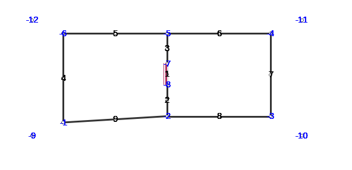

```python
>>> f,a=L.showG('s',nodes=True,slab=True,subseg=True,figsize=(10,10),labels=True)
```

L.ax provides the boundary of the layout with the following format : (xmin,xmax,ymin,ymax)

```python
>>> L.ax
```

```
(757.0, 770.0, 1110.955, 1116.545)
```

```python
>>> L.build()
```

```
building Layout ...
check len(ncycles) == 2 passed
```

This Layout has several convex cycles which are stored in the Gt graph. The diffraction points are stored in the dictionnary `L.ddiff`. The keys of this dictionnary are the diffraction points number and the values are a zipped list of output cycles and corresponding wedge angles.

```python
>>> L.Gv.node
```

```
{-8: {},
 -7: {},
 -6: {},
 -4: {},
 -3: {},
 -1: {},
 1: {},
 2: {},
 3: {},
 4: {},
 5: {},
 6: {},
 7: {},
 8: {},
 9: {},
 15: {},
 19: {},
 25: {},
 28: {}}
```

```python
>>> L.ddiff
```

```
{-8: ([7, 15], 6.283185307179586),
 -7: ([7, 15], 6.283185307179586),
 -6: ([14, 5], 4.7123889803846897),
 -4: ([14, 16], 4.7123889803846897),
 -3: ([11, 16], 4.7123889803846897),
 -1: ([5, 11], 4.7723171355059337)}
```

```python
>>> L.Gt.node
```

```
{0: {'hash': 'dafe0862efaaa8535a4a588c63fd1fd0', 'indoor': False},
 5: {'indoor': False,
  'inter': [(13, 5, 0),
   (13, 0, 5),
   (19, 5, 14),
   (19, 14, 5),
   (4, 5),
   (4, 5, 7),
   (4, 7, 5),
   (15, 5, 11),
   (15, 11, 5),
   (-3,),
   (-4,)],
  'isopen': True,
  'polyg': (757.0,1110.955)
  (757.0,1116.545)
  (758.5,1115.9)
  (758.5,1111.6)

  vnodes : (-9 13 -12 19 -6 4 -1 15 )},
 7: {'indoor': True,
  'inter': [(1, 7),
   (1, 7, 15),
   (1, 15, 7),
   (2, 7),
   (2, 7, 15),
   (2, 15, 7),
   (9, 7),
   (9, 7, 11),
   (9, 11, 7),
   (4, 7),
   (4, 7, 5),
   (4, 5, 7),
   (5, 7),
   (5, 7, 14),
   (5, 14, 7),
   (3, 7),
   (3, 7, 15),
   (3, 15, 7),
   (-3,),
```

[output cut: 90 more lines]

```
   (28, 16, 14),
   (28, 14, 16),
   (11, 16, 0),
   (11, 0, 16),
   (25, 16, 11),
   (25, 11, 16),
   (-3,),
   (-4,)],
  'isopen': True,
  'polyg': (768.5,1111.9)
  (768.5,1115.9)
  (770.0,1116.545)
  (770.0,1110.955)

  vnodes : (-3 7 -4 28 -11 11 -10 25 )}}
```

```python
>>> L=Layout('DLR.ini')
```

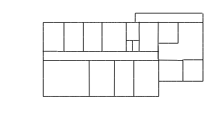

```python
>>> f,a=L.showG('s',aw=False)
```

To check which are the used slabs :

```python
>>> Slabs = np.unique(L.sla)
>>> for s in Slabs:
>>>     if s in L.sl:
           print L.sl[s]
```

```
3D_WINDOW_GLASS : GLASS | AIR | GLASS | [0.05, 0.05, 0.05]
       blue3 1

AIR : AIR | [0.05]
       white 1

DOOR : WOOD | [0.05]
       red1 1

METAL : METAL | [0.05]
       black 4

PARTITION : PLASTER | [0.05]
       grey80 4

WALL : BRICK | [0.05]
       grey20 3
```

Let's load an other layout. This an indoor office where the FP7 WHERE project UWB impulse radio measuremnts have been performed.

```python
>>> L=Layout('WHERE1.ini')
```

The showG method provides many possible visualization of the layout

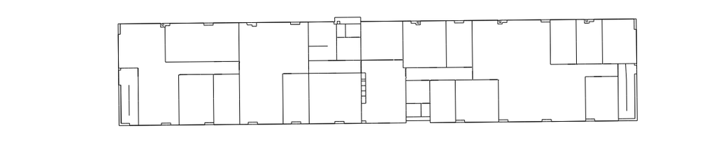

```python
>>> f,a=L.showG('s',airwalls=False,figsize=(20,10))
```

```
It exists degree 1 points : [-80]
```

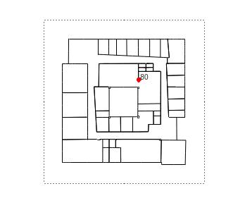

```python
>>> L=Layout('W2PTIN.ini')
```

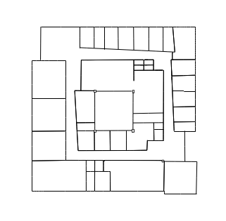

```python
>>> f,a = L.showG('s')
```

## The useful numpy arrays of the Layout

The layout data structure is a mix between graph and numpy array. numpy arrays are used when high performance is required while graph structure is convenient when dealing with different specific tasks. The tricky thing for the mind is to have to transcode between node index excluding 0 and numpy array index including 0. Below are listed various useful numpy array which are mostly used internally.

- tsg : get segment index in Gs from tahe
- isss : sub-segment index above Nsmax
- tgs : get segment index in tahe from Gs
- lsss : list of segments with sub-segment
- sla : list of all slab names (Nsmax+Nss+1)
- degree : degree of nodes

### `pt` the array of points

The point coordinates are stored in two different places

- L.Gs.pos : in a dictionary form (key is the point negative index)
- L.pt : in a numpy array

```python
>>> print np.shape(L.pt)
>>> print len(filter(lambda x: x<0,L.Gs.pos))
```

```
(2, 181)
185
```

This dual storage is chosen for computational efficiency reason. The priority goes to the graph and the numpy array is calculated at the end of the edition in the `Layout.g2npy` method (graph to numpy) which is in charge of the conversion.

### tahe (tail-head)

`tahe` is a $(2\times N_{s})$ where $N_s$ denotes the number of segment. The first line is the tail index of the segment $k$ and the second line is the head of the segment $k$. Where $k$ is the index of a given segment (starting in 0).

```python
>>> L.build()
```

```
building Layout ...
check len(ncycles) == 2 passed
```

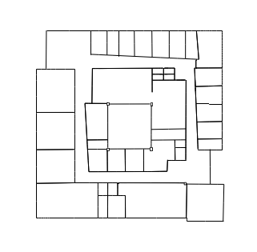

```python
>>> f,a = L.showG('s')
```

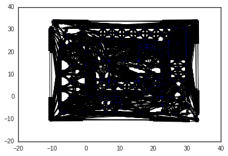

```python
>>> nx.draw_networkx_nodes(L.Gi,L.Gi.pos,node_color='blue',node_size=1)
>>> nx.draw_networkx_edges(L.Gi,L.Gi.pos,node_color='blue',node_size=1)
```

## `tgs` : trancodage from graph indexing to numpy array indexing

`tgs` is an array with length $N_s$+1. The index 0 is not used because none segment has 0 as an index.

```python
>>> ns = 5
>>> utahe = L.tgs[ns]
```

```python
>>> tahe =  L.tahe[:,utahe]
```

```python
>>> ptail = L.pt[:,tahe[0]]
>>> phead = L.pt[:,tahe[1]]
```

```python
>>> print ptail
```

```
[ 29.785   6.822]
```

```python
>>> print phead
```

```
[ 27.414   6.822]
```

```python
>>> L.Gs.node[5]
```

```
{'connect': [-8, -139],
 'name': 'PARTITION',
 'ncycles': [240, 245],
 'norm': array([ 0., -1.,  0.]),
 'offset': 0,
 'transition': False,
 'z': (0, 3.0)}
```

```python
>>> print L.Gs.pos[-8]
>>> print L.Gs.pos[-139]
```

```
(29.785, 6.822)
(27.414, 6.822)
```

```python
>>> aseg = np.array([4,7,134])
```

```python
>>> print np.shape(aseg)
```

```
(3,)
```

```python
>>> pt  = L.tahe[:,L.tgs[aseg]][0,:]
>>> ph = L.tahe[:,L.tgs[aseg]][1,:]
>>> pth = np.vstack((pt,ph))
```